```python
%%javascript
IPython.OutputArea.prototype._should_scroll = function(lines) {
    return false;
}
```

```python
# to load images for this tutorial
from IPython.display import Image
import os
path = os.getcwd()
```

# Post Overview.

1. Introduction to Two-Way ANOVA.
2. Discuss the Assumptions for a Two-Way ANOVA.
3. Mathematics of Two-Way ANOVA.
4. Demonstrate how to perform a Two-Way ANOVA using SPSS.

# Introduction to a Two-Way ANOVA.

**Two-Way ANOVA:**

- Is used to determine if there is an interaction effect between two independent variables (nominal) on a continuous dependent variable.
- A two-way ANOVA is used to determine how the mean of a quantitative variable changes according to the levels of two categorical variables.
- You use the two-way ANOVA when you want to know how two independent variables, in combination, affect a dependent variable.
- The independent variables are also called "factors" or "between-subject factors".
- The independent variables are nominal (categorical).
- ANOVA is short for Analysis of Variance.
- Two-way ANOVA is also known as:
  - Factorial ANOVA
  - Two-way between-subjects ANOVA
  - Two-way Analysis of Variance
- A Two-way ANOVA is an omnibus test statistic that can only tell if you if there is a statistically significant difference but does not tell you which specific groups were significantly different.
- If you have more than three groups, a follow-up test would need to be conducted to identify which of these groups differ from each other.
- A Two-way ANOVA is a parametric test.

**Variables used in this test are known as**

- Dependent variable that is measured in the continuous level.
- Two Independent (nominal) variables (grouping variable, or factor) that is divided into two or more mutually exclusive levels, or groups.

**Common Use Cases**

- Field studies
- Experiments
- Quasi-experiments

**Example Case Use**

- **Case** A pharmaceutical company wants to test two Alzheimer medications on elderly patients. The company wants to compare a standard drug to a new experimental, and how the drugs compare in early and severe Alzheimer. The company will evaluate the levels of Plasma Aβ in the blood.
- **Dependent Variable** Plasma Aβ in the blood.
- **Independent Variable** the two types of drugs.
- **Independent Variable levels** 1) current drug, and 2) new experimental drug.

**Aims of Two-way ANOVA**

- **Research Question Aim 1:** Is the experimental drug better or worse than the current drug at lowering plasma \(A\beta \).
- **Research Question Aim 2:** Whether the effect of the two drugs is different depending on if the elderly patient is classified as having either low or severe Alzheimer.
- **Research Question Aim 2:** Seems to determine if there is a statistically significant interaction effect.
- The result of the second aim will determine whether the first aim is misleading or incomplete.
- If statistically significant interaction exists, it indicates that the two levels (drugs) have different effects in the low and severe Alzheimer patients.
- The type of interaction will determine which effect in the two-way ANOVA that should be interpreted and any post hoc tests that can be performed.

**Hypothesis Statements**

- **Null Hypothesis \(H_{0} \):** The plasma \(A\beta \) levels are the same after treatment with either the current or new experimental drug.
- **Alternative Hypothesis \(H_{A} \):** The plasma \(A\beta \) levels are not the same after treatment with either the current or new experimental drug.

# Discuss the Assumptions for a Two-Way ANOVA.

**Assumptions**

In order to run this test, these assumptions must be considered. Failure to consider these assumptions can result in misleading and inaccurate conclusions.

1. You have one dependent variable that is measured on the continuous scale (ratio or interval).
2. You have two independent variable where each independent variable consists of two or more categorical and independent groups. If an independent variable only has two groups, then it is called a dichotomous variable. If it has three or more, it is referred to as a polytomous variable.
3. You have independent of observations, which means there is no relationship between the instances/observations in each group of the independent variable or between the groups. In other words, an instance cannot be present in more than one group.
4. There should be no significant outliers in the groups of your independent variable in terms of the dependent variable.
5. Your dependent variable (residuals) should be approximately normally distributed for each cell of the design.
6. You variance of the dependent variable should be equal in each cell of the design.

# Mathematics of a Two-Way ANOVA.

**Description**

- A two-way layout is such that there are two factors with at least two levels and one or more observation at each level.
- A two-way layout allows us to estimate the effect of each factor (main effects) as well as any interactions between the factors.
- The two-way ANOVA is used to assess the difference between the group means that are defined by two categorical factors.
- The two-way ANOVA is a hypothesis test that allows you to compare group means.
- The effect on the outcome of change in one variable (categorical explanatory) may either not depend on the level of the other variable *(additive model)* or it may depend on the level of the other variable *(interaction model)*.
- The error model in a Two-way ANOVA is the Normal Distribution with equal variance for all subjects that share the levels of all of the explanatory variables.
- The primary reason for running a two-way ANOVA is to establish whether there is an interaction effect between the two independent variables.
- The interaction effect occurs when the effect of one variable on a dependent variable is different at different levels of the other independent variable.
- For example, does the effectiveness of the Alzheimer medication depend on the severity of Alzheimer in the patient?
- This type of question is answered by determining whether there is a statistically significant interaction effect between the two independent variables (Medication (current or new) and Alzheimer severity(low or severe) in a two-way ANOVA.
- In the cross layout, we would have data that looks like this:

  |  | Current Medication | New Medication |
  | --- | --- | --- |
  | Mild Alzheimer | 37.55 | 39.72 |
  | Severe Alzheimer | 64.10 | 58.00 |

- This layout has 4 combination of groups from these two independent variables.
- A two-way ANOVA can determine the significance of these three effects: 1) an interaction effect and two main effects (Alzheimer severity, medication), and the interaction of those two.
- Interpretation of the main effects (medication and Alzheimer severity) depend on the interaction effect, and the main effects are considered after the interaction effect.

**Interactions**

- Two popular methods to understand interaction effects are **differences in simple main effects** and **difference in differences**.
- The interaction effect tells us whether the effect of medication on plasma \(a\beta\) is different for patients with severe and mild Alzheimer.
- The means we would compare two effects. (i) the effect of medication on the plasma \(a\beta\) in patients with mild Alzheimer and (ii) the effect of medication on the plasma \(a\beta\) in patients with severe Alzheimer.
- These two effects are called simple main effects (one for mild Alzheimer and one for severe Alzheimer).
- *A simple main effect is the effect of an independent variable on a dependent variable at a specific level of another variable*
- When we test for the interaction effect, we want to determine whether these two simple main effects are statistically significantly different.
- The interaction effect can be considered a test to determine if there are any differences in the simple main effects.
- If there is an interaction effect, then you can state the effect of the medication depends on the severity of Alzheimer and the reverse is also true.
- In our example, there are two main effects that we are comparing, the simple main effect of medication for a) mild and b) severe Alzheimer.
- In our example above, the difference in the current medication on Alzheimer severity is 64.10 - 37.55 = 26.55
- The difference in the new medication on Alzheimer severity is 58.0 - 39.72 = 18.28
- This would suggest that treatment with current medication has a larger amount of plasma \(a\beta\) in the Alzheimer patients than for those treated with the new medication (18.28). If there is no interaction effect and the effect of medication on the levels of plasma \(a\beta\) does not depend on Alzheimer severity, then you would expect these mean differences to be equal in the population (both the same value).
- The interaction effect is a test of whether the differences between these mean differences are statistically significantly different to zero.
- A profile plot is one of the easiest ways to make an initial judgment on whether an interaction effect exists, and will be discussed later.
- If the interaction effect is statistically significant, then you can follow up with simple main effects, or interaction contrasts.
- If the interaction effect is not statistically significant, then you can still follow up with the main effects

**Simple main effects, interaction contrasts, and Main effects**

- If there is a statistically significant interaction effect, we can run simple main effects and interpret and report their results. You will also have multiple simple main effects in your report.
- Interaction contrasts is another approach to follow up on statistically significant interaction effects. This method compares the differences between the two sets of differences. In our example, we would have a score for mild Alzheimer and one for severe Alzheimer, and the interaction contrast tests would determine if these two differences are difference in the population. Since this is a dichotomous variable, this boils down to a test between specific simple main effects of Alzheimer severity. Mild Alzheimer (37.55 - 39.72 = -2.17) and Severe Alzheimer (64.10 - 58.00 = 6.1) These two are not the same.
- If there was no statistically significant interaction effect, this indicates that the main effect of an independent variable is the same for each level of the independent variables. You can tell because the simple main effects are all equal.
- For example, the effect of the medication on the levels of plasma \(a\beta\) in patients with mild and severe Alzheimer is the same. This means you could possible ignore the severity Alzheimer and average the simple main effects. This method is only appropriate if you do not have an interaction effect.

**Model**

- If we have K observations at each combination of I levels of Factor A and J levels of Factor B, then we can model the two-way layout with the following form:  
  \[y_{ijk} = m + a_{i} + b_{j} + (ab)_{ij} + \epsilon_{ijk} \]

  The equation indicates
  1. \(k\)th data value for the \(j\)th level of Factor B and the \(i\) level of Factor A is the sum of the five components.
  2. \(\boldsymbol{m}\): the common value (grand mean)
  3. \(\boldsymbol{a_{i}}\): the level effect for Factor A
  4. \(\boldsymbol{b_{j}}\): the level effect for Factor B
  5. \(\boldsymbol{(ab)_{ij}}\): the interaction effect
  6. \(\boldsymbol{\epsilon_{ijk}}\): the residual

**Estimation**

- We display the data for a two-way ANOVA using a two-dimensional table with the levels of Factor A in columns and the levels of Factor B in rows.
- The replicate observations fill each cell, and we then get the common value, the row effects, the column effects, the interaction effects, and the residuals using the value-splitting technique.
- The sums of squares can be calculated and summarized in an ANOVA as shown below.

**Rows**

- **Sum of Squares:** \(SSR = JK\Sigma(\bar{y_{i}} - \bar{y})^{2}\)
- **DoF:** \(I-1\)
- **Mean Square:** \(MSR = \frac{SSR}{(I - 1)}\)
- **\(F_{0}\):** \(\frac{MSR}{MSE}\)

**Columns**

- **Sum of Squares:** \(SSC = IK\Sigma(\bar{y_{i}} - \bar{y})^{2}\)
- **DoF:** \(J-1\)
- **Mean Square:** \(MSC = \frac{SSC}{(J - 1)}\)
- **\(F_{0}\):** \(\frac{MSC}{MSE}\)

**Interactions**

- **Sum of Squares:** \(SSI = K\Sigma\Sigma(\bar{y_{ij}} - \bar{y_{i..}} - \bar{y_{.j.}} + \bar{y_{...}})^{2} \)
- **DoF:** \((I-1)(J-1)\)
- **Mean Square:** \(MSI = \frac{SSC}{((I - 1)(J - 1))}\)
- **\(F_{0}\):** \(\frac{MSi}{MSE}\)

**Residual**

- **Sum of Squares:** \(SSE = \Sigma\Sigma\Sigma(y_{ijk} - \bar{y_{ij}})^{2}\)
- **DoF:** \(IJ(K-1)\)
- **Mean Square:** \(MSE = \frac{SS_{F}}{(IJ(K - 1))}\)

**Coor.Total**

- **Sum of Squares:** \(SST = \Sigma\Sigma\Sigma(y_{ijk} - \bar{y_{..}})^{2}\)
- **DoF:** \(IJK-1\)

Where  
\[\bar{y_{i..}} = \frac{1}{JK}\Sigma_{j=1}^{J}\Sigma_{k=1}^{K}y_{ijk} \]  
\[\bar{y_{.j.}} = \frac{1}{IK}\Sigma_{i=1}^{I}\Sigma_{k=1}^{K}y_{ijk} \]  
\[\bar{y_{ij.}} = \frac{1}{K}\Sigma_{k=1}^{I}\Sigma_{K=1}^{K}y_{ijk} \]  
\[\bar{y_{..}} = \frac{1}{IJK}\Sigma_{i=1}^{I}\Sigma_{j=1}^{J}\Sigma_{K=1}^{K}y_{ijk} \]

- The row "Corr. Total" row contains the corrected total sum of squares and the associated degrees of freedom (DoF)
- The level effect must sum to zero. This is taken care of by most analysis programs automatically. By making the effect sum to zero, it applies a constraint to the model, and enables us to obtain a unique solution to the continuous linear model.

**Testing**

- We are testing if the two main effects and the interaction are zero
- This is models by using the ratio of each main effect mean square and the interaction mean square to the residual mean square.
- If the model follows a Gaussian distribution with fixed location and spread is true, then the ratios follow an F distribution and the test is performed by comparing the \(F_{0}\) ratios to the values in the F table, using the appropriate degrees of freedom and confidence interval.

**F Distribution and Critical Region**

- The critical values for an ANOVA hypothesis is found using the [F-table](http://www.socr.ucla.edu/Applets.dir/F_Table.html)
- The F-distribution is based on two types of degrees of freedom, there is one table for each possible value of alpha.
- The \(v_{1}\ =\ treatments\ -\ 1 \) corresponds to the numerator degrees of freedom
- The \(v_{2}\ =\ total\ observations\ minus\ treatments\ =\ N\ -\ t \) corresponds to the denominator degrees of freedom
- The critical value is the position in the F-Table where the intersection of these values meet  
  \[F^{v_{1},v_{2}}_{\alpha} = critical\ value \]
- The following steps are involved in the hypothesis testing process.
1. Specify the null \(H_{0} \) and alternate hypothesis \(H_{A} \).
2. Specify the level of significance \(\alpha \).
3. Calculate the \(F_{0}\) test statistic.
4. Determine the critical value using the test statistic value, the degrees of freedom value, and the F distribution table.

# Demonstrate how to perform a Two-Way ANOVA using SPSS.

#### Steps

1. Review case and organize variables, and set-up hypothesis.
2. Set up data in SPSS.
3. Confirm data does not violate assumptions.
4. Carry out Two-Way ANOVA.
5. Determine if interaction effect exists.
6. Reporting Summary.

### Set up data in SPSS

**SPSS Variable View**

- Either import or manually input data for the variables of interest.

**SPSS Data View**

[figure not shown]

```python
# Variable view
img = os.path.join(path, 'static/images/two_way_anova/spss1.png')
Image(filename=img,  width = 900)
```

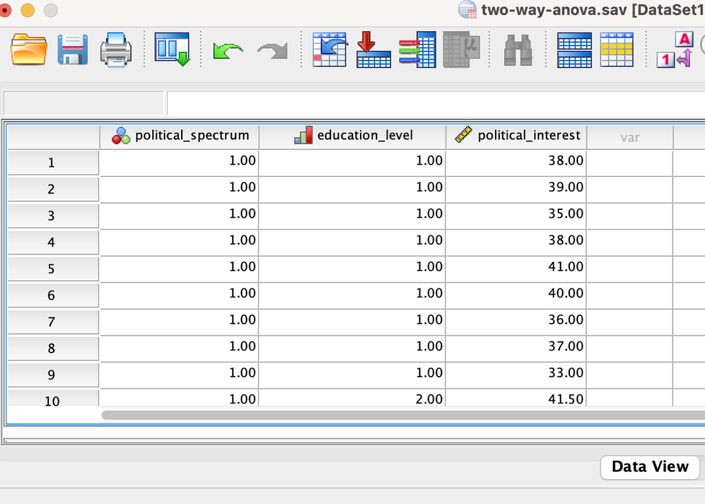

```python
# Data view
img = os.path.join(path, 'static/images/two_way_anova/spss2.png')
Image(filename=img,  width = 400)
```

### Confirm data does not violate assumptions

**Why confirm assumptions?**

[figure not shown]

```python
# Residuals
img = os.path.join(path, 'static/images/two_way_anova/spss3.png')
Image(filename=img,  width = 800)
```

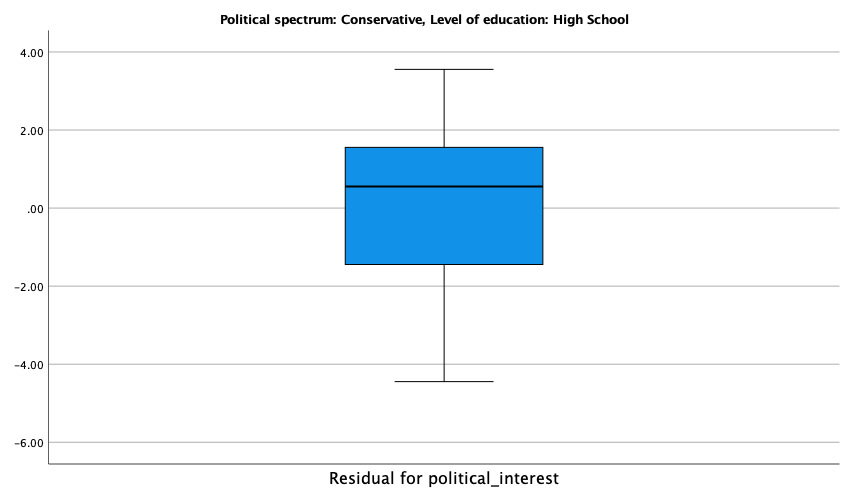

```python
# No outliers for residuals of conservative and highschool combination
img = os.path.join(path, 'static/images/two_way_anova/spss4a.png')
Image(filename=img,  width = 400)
```

[figure not shown]

```python
# No outliers for residuals of conservative and highschool undergrad
img = os.path.join(path, 'static/images/two_way_anova/spss4b.png')
Image(filename=img,  width = 400)
```

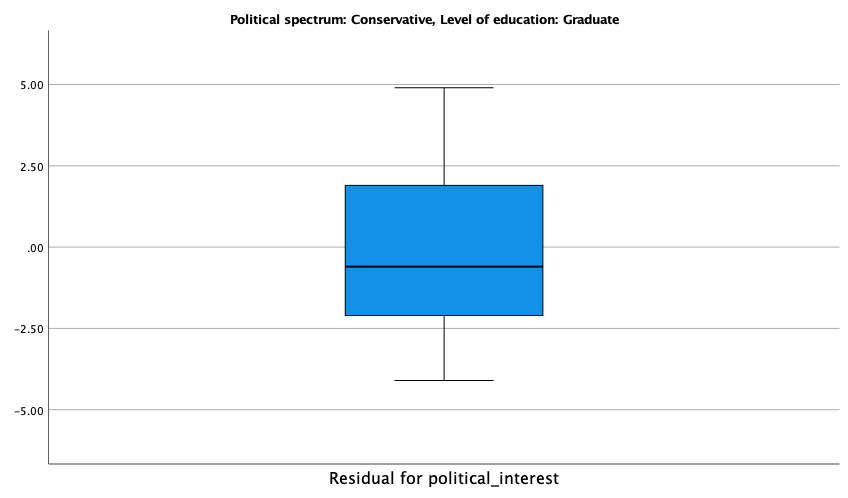

```python
# No outliers for residuals of conservative and graduate
img = os.path.join(path, 'static/images/two_way_anova/spss4c.png')
Image(filename=img,  width = 400)
```

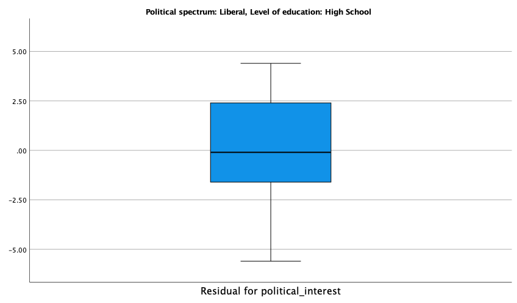

```python
# No outliers for residuals of liberal and high school combination
img = os.path.join(path, 'static/images/two_way_anova/spss4d.png')
Image(filename=img,  width = 400)
```

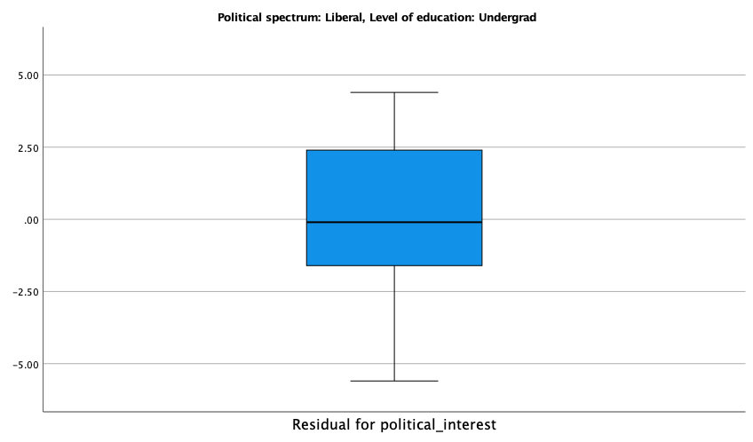

```python
# No outliers for residuals of liberal and undergrad combination
img = os.path.join(path, 'static/images/two_way_anova/spss4e.png')
Image(filename=img,  width = 400)
```

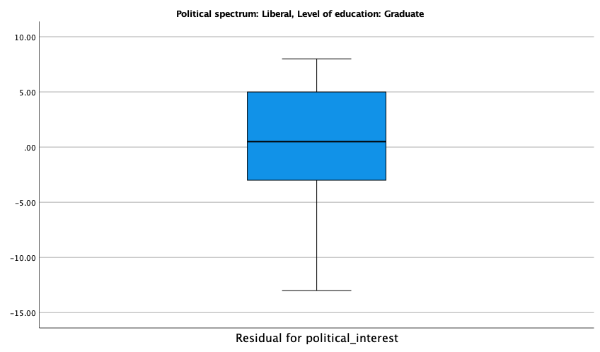

```python
# No outliers for residuals of liberal and graduate combination
img = os.path.join(path, 'static/images/two_way_anova/spss4f.png')
Image(filename=img,  width = 400)
```

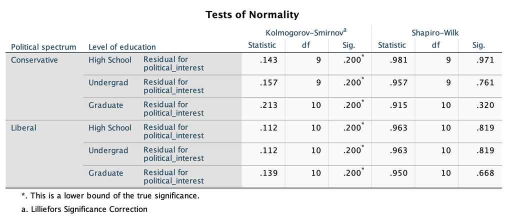

```python
# Shapiro-wilk test for normality on all combination of independent variables
img = os.path.join(path, 'static/images/two_way_anova/spss5.png')
Image(filename=img,  width = 600)
```

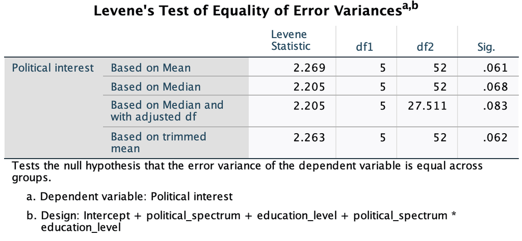

```python
# Levene's test for equal variance on residuals of political interest score
img = os.path.join(path, 'static/images/two_way_anova/spss5b.png')
Image(filename=img,  width = 500)
```

### Carry out the Two-Way ANOVA.

**Procedure**

1. `Analyze > General Linear Model > Univariate`
2. **Univariate dialogue box**: `Political Interest Residual scores to dependent list box > independent variables into Fixed Factor(s) box > Click Plots button`
3. **Univariate Profile Plots dialogue box**: `Education on horizontal axis and political spectrum in separate lines > Click Add, will add combination in plots box > Click Continue`
4. **Univariate dialogue box**: `Click Post Hoc button > The Univariate: Post Hoc Multiple Comparisons for Observed Means will open`
5. **Univariate: Post Hoc Multiple Comparisons for Observed Means dialogue box**: `Transfer education level independent variable to post hoc test box > Click Tukey in equal variance assumed section > Click Continue`
6. **Univariate dialogue box**: `Click Options`
7. **Univariate: Options dialogue box**: `Transfer independent variables and the interaction fromt he factors and factor interaction box into the Display Mean for box > In display area, tick Descriptive statistics option > click continue botton`
8. **Univariate dialogue box**: `Click OK button` to generate Output.

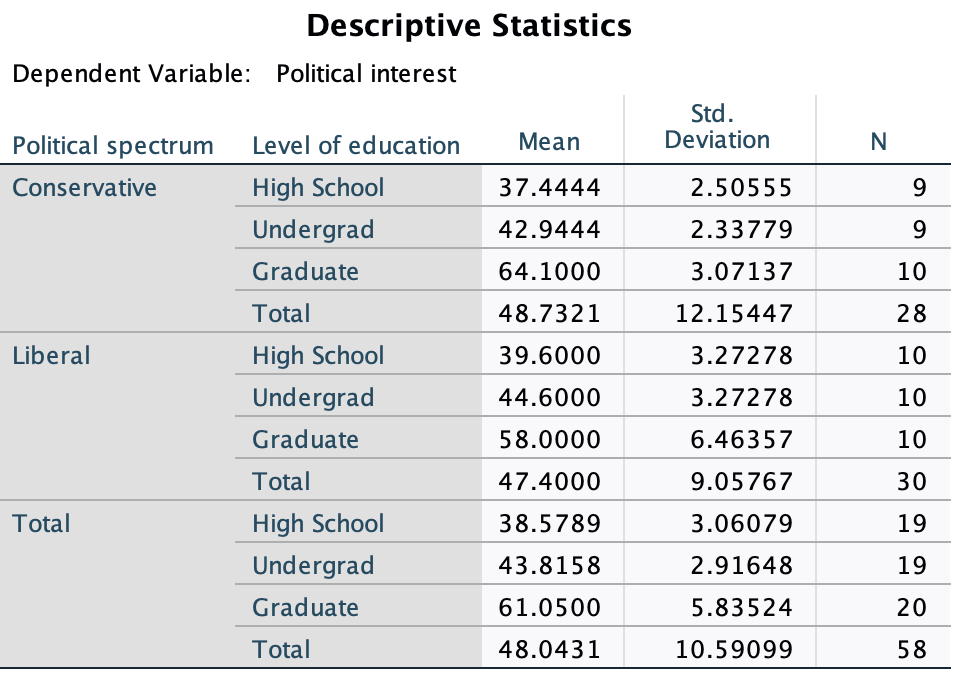

```python
# Basic descriptive overview of central tendencies between combination of independent variabels
img = os.path.join(path, 'static/images/two_way_anova/spss6.png')
Image(filename=img, width=450)
```

**Descriptive Statistic Table.**

- Provides the mean and standard deviation for each combination of independent variables (groups, also referred to as each "cell" of the design)
- The "Total" rows provides means and standard deviations for groups only split by one independent variable, or none at all. This is useful if no statistically significant interaction exists.

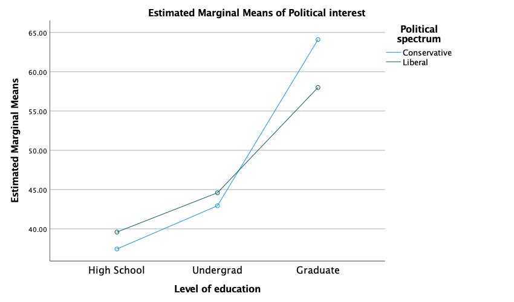

```python
# OEM Means
img = os.path.join(path, 'static/images/two_way_anova/spss7.png')
Image(filename=img,  width = 650)
```

**Estimated Marginal Mean of Political Interest.**

- This plot is used to determine if interaction between the two independent variables exist.
- We defined the education level as the focal variable and the political spectrum as the moderator variable.
- We are primarily interested in determining whether the the level of education effects interest in politics is different between those that identify as liberal versus conservative.
- Visual inspection of the profile plots (GLM univariate plots step) generated is a useful method
- If the lines are not parallel (the cross or overlap each other), then you might have an interaction effect.
- If the lines are parallel, you might not expect an interaction effect
- This is just a guiding tool but these plots are based from sample data, and we want to determine whether the interaction effect in the population.
- Any non-parallel line in the profile plot might be due to sampling error and may not reflect non-parallel lines in the population.
- In this example, the lines do cross one another. This is a disordinal interaction. If the lines did not cross, then we would have an ordinal interaction. The distinction might have implications on the main effects.

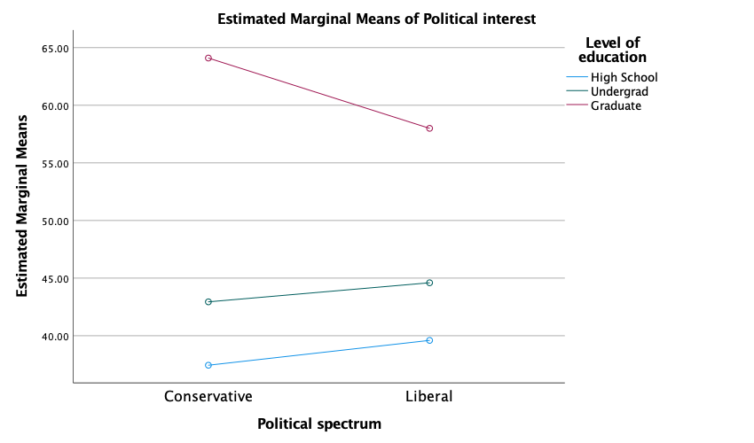

```python
# OEM Means
img = os.path.join(path, 'static/images/two_way_anova/spss8.png')
Image(filename=img, width=650)
```

**Estimated Marginal Mean of Political Interest.**

- The political interest for conservative and liberal individuals increases with education.
- The pattern of increase in politics is not the same between conservative and liberals.
- Conservatives have lower interest in politics than liberals when education is high school and undergrad, but relation reverses with graduate education.
- The test of between-subjects effects table is used to determine whether there is statistically significant interactions.

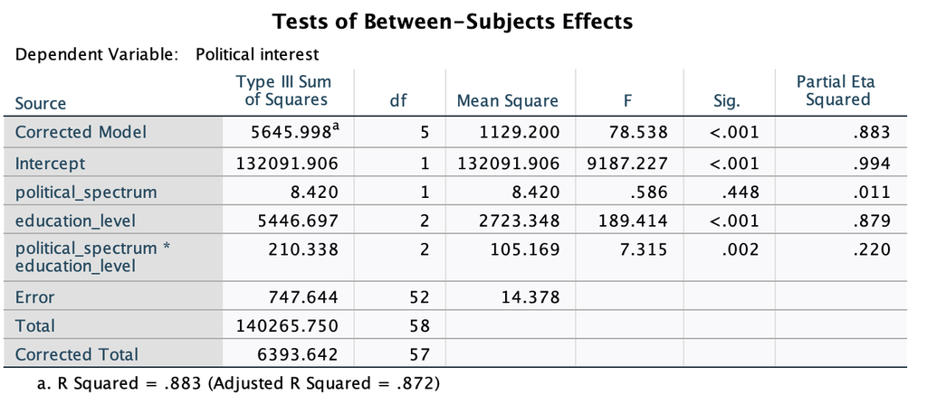

```python
# Tests of between-subject effects
img = os.path.join(path, 'static/images/two_way_anova/spss9.png')
Image(filename=img, width=800)
```

**Tests of between-subjects effects table.**

- The interaction effect is represented as the product of the two independent variables `political_spectrum * education_level`.
- Looking at the source row for this combination we see that the Sig p-value = 0.002, which is below the level of significance 0.05, we can conclude that the interaction effect is statistically significant.
- Significant interaction effect suggest that the effect of education level on political interest score depends on the whether the individuals political identity. The effect of political identity on political interest score depends on the level of education.
- When an interaction term is statistically significant, this indicates that the effect of one of the independent variables on the dependent variable depends on the level of the other independent variable.
- The partial Eta squares \( \eta^{2} \) is a measure of the effect size.
- The p value indicates the probability of obtaining the observed F-value given the null hypothesis is true.
- If there was no statistically significant interaction effect, then we would look at whether there were any statistically significant main effects.
- Since we have a statistically significant interaction effect, we would look at whether there were any statistically significant simple main effects.

### Simple Main Effects.

**Ordinal or Disordinal interactions**

- **Ordinal Interactions:** are interactions where the lines do not overlap or cross over and are not parallel.
- **Disordinal Interactions:** are interactions where the lines do overlap or cross over and are not parallel.
- We have a disordinal interaction, and no main effects reporting is needed.
- To carry out the simple main effects in SPSS requires the use of the syntax method and not the point and click approach.
- This method also uses the overall error term of the two-way ANOVA for the simple main effects rather than an error term specific to each independent variable as you would get in a simple one-way ANOVA.

**Procedure**

1. `Analyze > General Linear Model > Univariate`
2. **Univariate dialogue box**: `Click save > Univariate: Save dialogue box > Uncheck Unstandardized, Unstandardized, Studentized (this will prevent adding more variables to the dataset) > Click Continue button`
3. **Univariate: Options dialogue box**: `Select Estimates of effect size in display area > Click Continue`
4. **Univariate dialogue box**: `Click Paste Button` IBM SPSS Statistics Syntax Editor window > Code used to generate simple main effects depicted in next image below > Run on tool bar > All button to run code.

[figure not shown]

```python
# SPSS Syntax for simple main effects
img = os.path.join(path, 'static/images/two_way_anova/spss10.png')
Image(filename=img, width=700)
```

## Simple Main Effects for Political Spectrum Identity

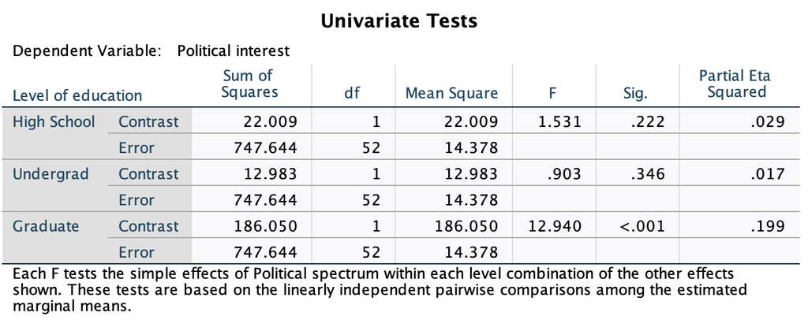

```python
# Univariate tests
img = os.path.join(path, 'static/images/two_way_anova/spss11.png')
Image(filename=img, width=550)
```

- We are interested in the simple main effect for political identity are the effects of political identity at each level of education.
- So the simple main effect of political identity at "High School", "Undergrad", and at "Graduate" level.
- The three simple main effects are presented in the univariate tests table above, and is used to determine whether the simple main effect is statistically significant (whether there is a difference between the means.
- **Simple main effect of Political Identity for those with High School education:** Political identity is a dichotomous variable in this study, so we are comparing the difference in the mean for political interest score between high school educated liberal and conservative individuals. We see that the \[p=0.222 > \alpha(0.05)\] which indicates that this combination is not significant.
- The only significant simple main effect is for graduate education level and political identity (spectrum) \[p =.001 < \alpha(0.05) \]. This indicates that we have a statistically significant simple main effect when comparing the mean political interest score between graduate educated liberal and conservative individuals.
- There was a statistically significant difference in mean "Political Interest" score between liberals and conservatives who had a graduate education, F(1, 52) = 12.94, p = .001, partial \( \eta^{2} \) = .199.

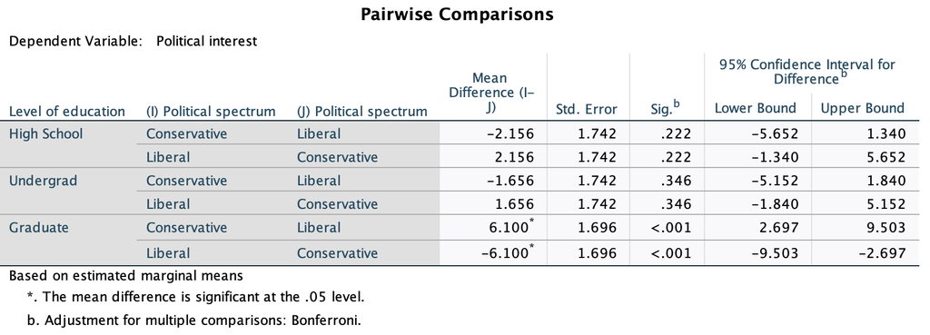

```python
# Pairwise comparisons
img = os.path.join(path, 'static/images/two_way_anova/spss12.png')
Image(filename=img, width=700)
```

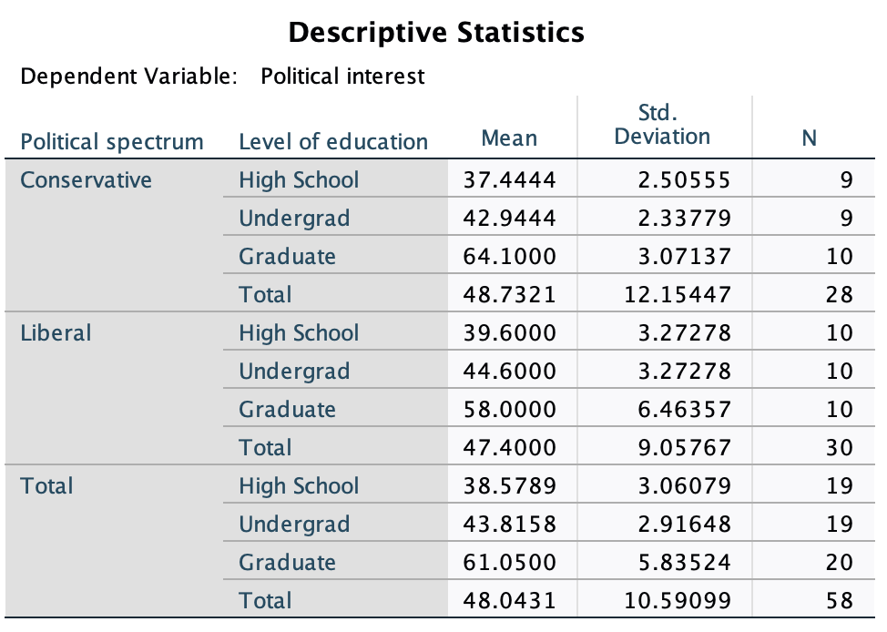

```python
# Descriptive statistics
img = os.path.join(path, 'static/images/two_way_anova/spss13.png')
Image(filename=img, width=500)
```

**Pairwise Comparison**

- Provides the same information as the univariate test but also provided the 95% confidence interval and the difference between the independent variable groups.
- In the pairwise comparison table, we see in the last two rows for Graduate level of education, the p-value is less than .001, with corresponding 95% confidence intervals, and the difference between these two groups as 6.10 points..
- For liberals and conservatives with a graduate education, the mean "Political Interest" score was 6.10 (95% CI, 2.70 to 9.50) points higher for conservatives than liberals, F(1, 52) = 12.94, p = .001, partial \(\eta^{2} \) = .199..
- You can confirm the score differences from the descriptive statistics table. The mean for conservative graduate educated individuals were 64.10 and that for liberals at 58.00. The difference is 6.10.

## Simple Main Effects for Education Level

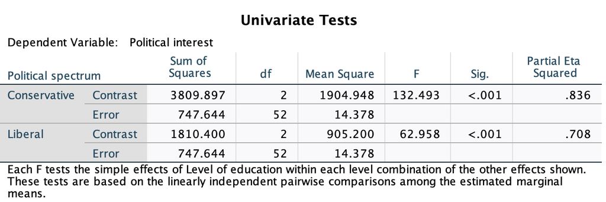

```python
# Political interest and political identity univerate test
img = os.path.join(path, 'static/images/two_way_anova/spss14.png')
Image(filename=img, width=700)
```

**Simple main effects for education level**

- The simple main effects for education level are the effects of education at each level of political identity.
- These two simple main effects are represented in the univariate table above.
- **Simple main effect of education for liberals:** Here we are testing for differences in the mean political score between high school, undergrad, and graduate educated liberals. We see that the \[p=0.001 < \alpha(0.05)\] which indicates that this combination is significant.
- **Simple main effect of education for conservatives:** Here we are testing for differences in the mean political score between high school, undergrad, and graduate educated conservatives. We see that the \[p=0.001 < \alpha(0.05)\] which indicates that this combination is significant.
- There was a statistically significant difference in mean "Political Interest" scores between liberal educated to either high school, undergraduate or graduate level, F(2, 52) = 62.96, p $<$ .001, partial \(\eta^{2} \) = .708.
- There was a statistically significant difference in mean "Political Interest" scores between conservative educated to either high school, undergraduate or graduate level, F(2, 52) = 132.493, p $<$ .001, partial \(\eta^{2} \) = .836.

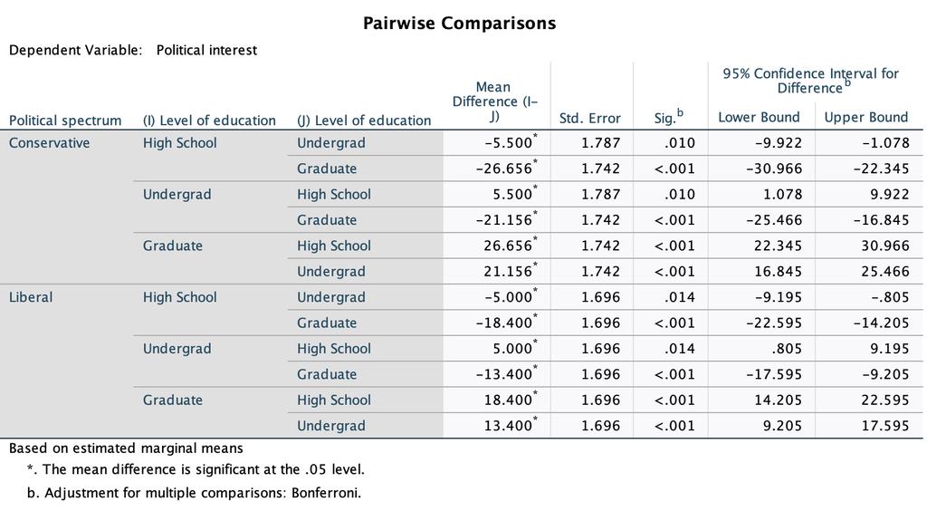

```python
# Pairwise Comparisons
img = os.path.join(path, 'static/images/two_way_anova/spss15.png')
Image(filename=img, width=800)
```

**Pairwise comparisons**

- The pairwise comparison table will display the differences in the mean political interest score for conservatives and liberals at different levels of education.
- The sig column indicates provides the p-value for each pairwise comparison, and all are less than the level of significance 0.05.

### Reporting Summary.

**Two-way ANOVA Set-up**

- A two-way ANOVA was conducted to examine the effects of political identity and education level on interest in politics. Data are mean ± standard deviation, unless otherwise stated. Residual analysis was performed to test for the assumptions of the two-way ANOVA. Outliers were assessed by inspection of a boxplot, normality was assessed using Shapiro-Wilk's normality test for each cell of the design and homogeneity of variances was assessed by Levene's test. There were no outliers, residuals were normally distributed (p $>$ .05) and there was homogeneity of variances (p = .061). .

**Pair-wise Comparisons**

- There was a statistically significant interaction between political identity and level of education on interest in politics, F(2, 52) = 7.315, p = .002, partial η2 = .220. Therefore, an analysis of simple main effects for education level was performed with statistical significance receiving a Bonferroni adjustment and being accepted at the p $<$ .025 level. There was a statistically significant difference in mean "Political Interest" scores for liberals educated to either school, college or university level, F(2, 52) = 62.96, p $<$ .0005, partial η2 = .708, as for conservatives, F(2, 52) = 132.493, p $<$ .0005, partial \(\eta^{2} \) = .836..

**Conservative and Level of Education**

- Mean "Political Interest" scores for high school-educated, undergrad-educated, and graduate-educated conservatives were 37.44 ± 2.51, 42.94 ± 2.34 and 64.10 ± 3.07, respectively. High School-educated conservatives had a statistically significantly lower mean "Political Interest" score than undergrad-educated conservatives, 5.50 (95% CI, 1.08 to 9.92), p = .010, and graduate-educated conservatives, 26.66 (95% CI, 22.35 to 30.97), p $<$ .0005. Undergrad-educated conservatives also had a statistically significantly lower mean "Political Interest" score than graduate-educated conservatives, 21.16 (95% CI, 16.85 to 25.47), p $<$ .0005.